# LAB 3: Topic modeling

Use topic models to explore hotel reviews

Objectives:

- tokenize with MWEs using spacy
- estimate LDA topic models with tomotopy
- visualize and evaluate topic models
- apply topic models to interpretation of hotel reviews

```python
!pip install -q spacy[cuda11x] tomotopy
```

```python
import numpy as np
import pandas as pd
import tomotopy as tp
import spacy
from textwrap import fill
from tqdm.auto import tqdm
tqdm.pandas()

pd.options.mode.copy_on_write = True
```

Select a sample of reviews to work with

```python
df = pd.read_parquet("../lab-02/hotel_review.parquet")
df = df.sample(frac=0.025, random_state=619)
df['review'] = df['title'] + " " + df['text']
```

Tokenize reviews

```python
mwt = spacy.load('../lab-02/mwt')
```

```python
df["tokens"] = [[t.norm_ for t in doc if not t.is_space] for doc in mwt.pipe(tqdm(df['review']))]
```

```python
pd.set_option("display.max_colwidth", 200)
df['tokens'].head()
```

```
508532    [", ramada, plaza, 12027, n., 28th, drive, ,, phoenix, az, ", when, i, first, checked, in, this, weekend, ,, i, had, to, request, another, room, 210, due, to, the, stench, smell, ., the, next room...
191393    [", location, ,, location, ,, location, !, ", you, can, not, beat, this, location, :, only, two, blocks, from, the, subway, and, within, comfortable, walking distance, of, many, nyc, attractions, ...
104804    [", worst, hotel, i, have, ever, stayed, at, ., ", this, is, hands, down, the, worst, hotel, i, have, ever, stayed, at, ., i, had, heard, people, rave, of, this, ", hip, ", hotel, in, new york, so...
165828    [", solid, hotel, and, good location, ", stayed, at, the, park, south, hotel, in, mid-, september, and, found, this, to, be, good value, hotel, with, a, very, convenient location, ., the, free bre...
209506    [", molto, carino, ,, ottima, posizione, ", sono, stato, all'hotel, mela, per, lavoro, ., e, ', un, design, hotel, molto, carino, ., le, staze, sono, nuove, ,, pulite, e, grandi, ., servizio, cort...
Name: tokens, dtype: object
```

## Estimate LDA

These are the model **hyperparameters**: aspects of the model that aren't estimated from the data but have to be set in advance by the analyst. There's no "right" values for these. You'll just have to try out different values to find settings that give you a model that you can interpret:

- *k* = number of topics
- *min_df* = minimum number of reviews that a term has to occur in to be included in the model
- *rm_top* = number of most frequent terms to remove from the model
- *tw* = term weighting strategy (described [here](https://bab2min.github.io/tomotopy/v0.10.1/en/#tomotopy.TermWeight))
- *alpha, eta* = priors for document-topic and topic-word distributions
- *tol* = convergence tolerance

Here's where we do the work. The documentation for `LDAModel` is [here](https://bab2min.github.io/tomotopy/v0.12.6/en/#tomotopy.LDAModel). You might also consider trying out one of the other model types (e.g., `HDPModel`).

Some other things to try: increase *k* to get more fine-grained topics; increase *rm_top* to filter out more functions words; adjust priors and term weighting; use an asymmetric prior for the document-topic distribution (something like `alpha = [(i+1)*np.sqrt(1/k) for i in range(k)]`)

```python
k = 25
min_df = 100
rm_top = 25
tw = tp.TermWeight.ONE
alpha = 0.1
eta = 0.01
tol = 1e-4
```

Here's where we do the work. The closer *LL* is to zero, the better the model fits the data.

```python
%%time

mdl = tp.LDAModel(k=k, min_df=min_df, rm_top=rm_top, tw=tw, alpha=alpha, eta=eta)

for doc in df["tokens"]:
    if doc:
        mdl.add_doc(doc)

mdl.train(0)
last = mdl.ll_per_word
print(f"{0:5d} LL = {last:8.4f}", flush=True)

for i in range(50, 5000, 50):
    mdl.train(50, workers=2)
    ll = mdl.ll_per_word
    print(f"{i:5d} LL = {ll:8.4f}", flush=True)
    if ll - last < tol:
        break
    else:
        last = ll

print(f"Done!")
```

```
    0 LL = -10.5513
   50 LL =  -7.7280
  100 LL =  -7.6282
  150 LL =  -7.5918
  200 LL =  -7.5763
  250 LL =  -7.5651
  300 LL =  -7.5549
  350 LL =  -7.5544
  400 LL =  -7.5467
  450 LL =  -7.5423
  500 LL =  -7.5410
  550 LL =  -7.5407
  600 LL =  -7.5361
  650 LL =  -7.5343
  700 LL =  -7.5331
  750 LL =  -7.5318
  800 LL =  -7.5288
  850 LL =  -7.5308
Done!
CPU times: user 2min 45s, sys: 659 ms, total: 2min 45s
Wall time: 1min 24s
```

## Examine the model

Which terms got removed due to `rm_top`? If any of these look like they might be relevant to hotel reviews, then `rm_top` is probably too big.

```python
print(mdl.removed_top_words)
```

```
['the', '.', ',', 'and', 'a', 'to', 'was', 'i', '"', 'in', 'we', 'of', 'is', 'for', 'it', 'hotel', 'not', '!', 'room', 'at', 'but', 'were', 'this', 'on', 'with']
```

Use LDAvis algorithm to plot.

```python
import matplotlib.pyplot as plt
from scipy.spatial import distance
from sklearn.manifold import MDS, TSNE


def plot_topics(mdl, method="tsne", figsize=7):

    fig = plt.figure(figsize=(figsize, figsize))

    # x, y coords
    term_topics_dist = np.stack([mdl.get_topic_word_dist(k) for k in range(mdl.k)])
    if method == "mds":
        dist = distance.squareform(distance.pdist(term_topics_dist, "jensenshannon"))
        coords = MDS(2, dissimilarity="precomputed").fit_transform(dist)
    elif method == "tsne":
        if mdl.k <= 20:
            p = mdl.k - 1
        else:
            p = 20
        coords = TSNE(
            2,
            metric=distance.jensenshannon,
            perplexity=p,
            init="pca",
            learning_rate="auto",
            n_jobs=-1,
        ).fit_transform(term_topics_dist)
    else:
        raise ValueError(f"Method {method} unknown")

    # size of the circle
    doc_topic_dists = np.stack([doc.get_topic_dist() for doc in mdl.docs])
    doc_lengths = np.array([len(doc.words) for doc in mdl.docs])
    words_per_topic = np.dot(doc_topic_dists.T, doc_lengths)
    topic_percent = words_per_topic / words_per_topic.sum()
    sizes = topic_percent * (figsize * fig.dpi) * (figsize * fig.dpi) * (0.25 / 3.14)

    # draw it
    plt.scatter(coords[:, 0], coords[:, 1], s=sizes, alpha=0.3)
    for i in range(mdl.k):
        plt.text(coords[i, 0], coords[i, 1], i, ha="center", va="center")
        plt.tick_params(left=False, bottom=False, labelleft=False, labelbottom=False)
```

We'd like to see topics evenly spread out in space without too much overlap. If the circles are all very large with a lot of space between them, then we need more topics. If there are lots of tiny topics or the topcs overlap substantially, then we might have too many topics.

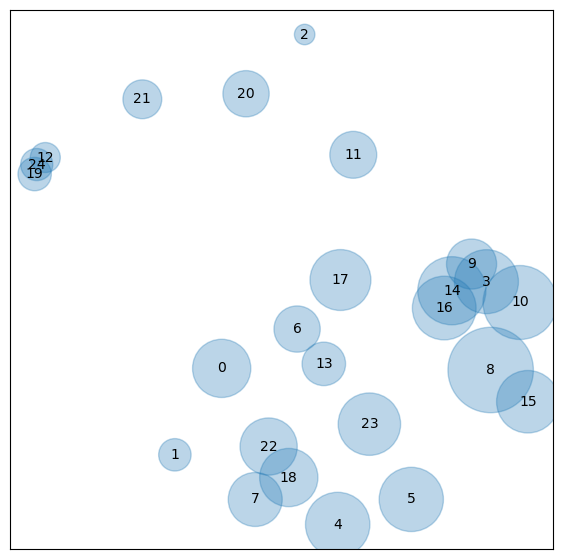

```python
plot_topics(mdl)
```

## Interpret the model

What terms are associated with each topic? = $p(w|z)$

```python
for k in range(mdl.k):
    print(fill(' '.join(s for s, _ in mdl.get_topic_words(k, 50)),
               initial_indent=f'{k:<5d}',
               subsequent_indent='     ',
               width=100))
    print()
```

```
0    from there you 's street ) ( walk away location about also right or across city blocks within
     restaurants area bus which just are downtown walking distance block park only close get as
     around boston so great metro if that shopping can one / located by $ center easy mall stop

1    's san francisco from union square location - street city wharf inn sf very are clean area
     around all right great walk fisherman restaurants shopping cable car helpful great location an
     close walking distance located bart staff just bay hollywood across block within place
     chinatown motel powell hill away bus easy blocks walking friendly comfortable

2    ... & .. .... * ? ..... / 2 etc ' just 5 3 1 place best 4 ...... am big check 1st :) coffee
     huge old why ok roof c awesome oh u pool top its rest stars keep austin cool me b red yes plus
     s girls w

3    our us had they out up when so that there check would after back got minutes time get arrived
     night about one before do went just ready all could which be car checked very 2 have took early
     no luggage from down around front desk came did airport bags until wait

4    very stay clean here would again staff stayed great nice friendly helpful comfortable my had
     definitely location rooms will great location recommend our really everything close great hotel
     there good quiet nights bed back night beds place enjoyed spacious loved all breakfast well
     price be staying super excellent great place wonderful extremely little

5    our my staff us stay from all service had made very as will wonderful every best friendly great
     by helpful who home have always they trip make experience stayed amazing so their feel husband
     time perfect recommend out everyone special be an family excellent even everything back
     concierge way 's

6    breakfast coffee there free - good also morning day they tea had have which from or food eggs
     you as evening included hot all / fruit nice wine complimentary very available one restaurant
     could drinks well each lobby only bagels bar no every clean juice has snacks some etc cereal

7    - are great service rooms bar an restaurant has beautiful lobby very 's view location from city
     well chicago all views staff best amazing modern excellent wonderful decor loved stayed as food
     fantastic have experience lounge my boston new comfortable floor top love w hotels cool ;
     lovely also restaurants

8    have that you are my they be as so do 's there about one like stay been if can am more me all
     here stayed or hotels just will would what than some has really place their get - say because
     when people time much any could out rooms most

```

[output cut: 52 more lines]

```
     frühstück super direkt etwas ) gibt wieder alles

22   from nyc new york location times square very all clean great subway just stayed staff helpful
     our manhattan would are ny as had rooms small great location central park city there nights
     good walk - friendly broadway which so away comfortable day recommend excellent 2 street around
     close also again stay about you only

23   very good are nice rooms there small clean bit location really 's breakfast which as do too
     little that if you staff be price would much pretty some quite overall so ok just great area
     like than close fine nothing more good location expensive though lobby food however although
     get better

24   de en y la que el muy es no un para o e lo con las una por del los se pero é al bien excelente
     te nos da todo um habitaciones mas si este habitación me buena como do personal son van times
     square je ... mi era metro café
```

Which documents best reflect each topic?

```python
def print_topic_docs(topic, n_best=3):
    topic_weights = sorted(
        [(doc.get_topic_dist()[topic], i) for i, doc in enumerate(mdl.docs)],
        reverse=True,
    )
    for i in range(n_best):
        print(fill(df["review"].iloc[topic_weights[i][1]],
                   initial_indent='  ', subsequent_indent='  ',
                   width=100))
        print()
```

```python
print_topic_docs(1)
```

```
  “Good location on Union Square” Nice hotel with a great location right on Union Square. Plenty of
  good restaurants and shopping within walking distance. Catch the cable car right outside the hotel
  for the waterfront. Older, smallish but very comfortable rooms but an elegant hotel lobby. Staff
  was excellent and very helpful.

  “great location!!” This hotel is perfect for touring the city of Memphis. It is across the street
  from the pricier Peabody,(and their ducks!) around the corner from the famous restaurant the
  Rendezvous and three blocks from Beale street. The room was spacious and clean and the staff was
  very helpful. Perfect for the average vacationer.

  “Excellent Location” The hotel is excellent. You can't ask for a better location, right on the
  edge of Fisherman's Wharf and right next to the Hyde Street Cable Cars. Also about 1-2 blocks from
  Ghirardelli Square. Lots of restaurants in the area. Very safe to walk around at night. The free
  wine from 5-6pm is a nice perk. Staff all very friendly and helpful.  Highly recommended
  especially when you see the hotels in the Union Square district...those people are all down at
  Fisherman's Wharf anyway so why not be where all the action is.
```

```python
for topic in range(mdl.k):
    print(f"Topic = {topic} ({', '.join(s for s, _ in mdl.get_topic_words(topic))})")
    print()
    print_topic_docs(topic)
    print("--")
```

```
Topic = 0 (from, there, you, 's, street, ), (, walk, away, location)

  “Nice Location in Downtown” Nice clean hotel right across the street from Grant Park. Great
  location to many downtown destinations. Staff was very helpful. On site parking for a fee is a
  good idea because of its location you can walk or find an L train or the subway only blocks away
  which can vurtually take you anywhere in the city. Soldier Field, Shedd Aquarium, Field Museum,
  Grant Park and Cloud Gate are just a short distance walk from hotel. Navy Pier is just over a mile
  walk too.

  “Business trip in Denver” Had a wonderful stay at the Magnolia Hotel in Denver would definitely
  stay there again. The location is one block from the 16th street Mall where you can catch a free
  bus ride up and down the main street. The bus drops you within walking distance of the baseball
  field if you want to go see a MLB game.

  “HIGH END MARRIOTT NEAR NATIONAL ZOO” EXCELLENT LOCATION - Near metro or short cab rides
  everywhere.

--
Topic = 1 ('s, san francisco, from, union square, location, -, street, city, wharf, inn)

  “Good location on Union Square” Nice hotel with a great location right on Union Square. Plenty of
  good restaurants and shopping within walking distance. Catch the cable car right outside the hotel
  for the waterfront. Older, smallish but very comfortable rooms but an elegant hotel lobby. Staff
  was excellent and very helpful.

  “great location!!” This hotel is perfect for touring the city of Memphis. It is across the street
  from the pricier Peabody,(and their ducks!) around the corner from the famous restaurant the
  Rendezvous and three blocks from Beale street. The room was spacious and clean and the staff was
  very helpful. Perfect for the average vacationer.

  “Excellent Location” The hotel is excellent. You can't ask for a better location, right on the
  edge of Fisherman's Wharf and right next to the Hyde Street Cable Cars. Also about 1-2 blocks from
  Ghirardelli Square. Lots of restaurants in the area. Very safe to walk around at night. The free
  wine from 5-6pm is a nice perk. Staff all very friendly and helpful.  Highly recommended
  especially when you see the hotels in the Union Square district...those people are all down at
  Fisherman's Wharf anyway so why not be where all the action is.

--
Topic = 2 (..., &, .., ...., *, ?, ....., /, 2, etc)

```

[output cut: 568 more lines]

```
  conexiones. El edificio Chrysler se ve desde la esquina de la calle del hotel, queda muy cerca. La
  verdad que volvería a este hotel con los ojos cerrados!!!!

  “Elección genial” Nos inclinamos por este hotel al descubrir que era de nueva apertura y el precio
  era estupendo para lo que se ve por NY. Y no nos equivocamos. Como el nombre indica está en la
  calle 26. Tiene cerca de todo: restaurantes, supermercados, farmacias, tiendas... En la recepción
  tienen para los clientes "cupcakes", las cuales están deliciosas. También al lado de la recepción
  cuentas con un cuarto con dos ordenadores a disposición de los clientes, totalmente gratuito.
  Disponen de wifi gratuito en todo el hotel. La habitación, como el hotel era nueva, el baño amplio
  y estupendo, tv de pantalla plana, cafetera, etc. El armario un poco pequeño. El hotel cuenta con
  un restaurante "Rare", principalmente de hamburguesas, pero "de lujo". Nosotros cenamos la primera
  noche y la verdad que tanto el servicio como la comida estuvo muy bien. El personal del hotel fue
  muy amable en todo momento. Sin duda regresaría.

--
```

### Happy with what you've got? Then save the final, best model

```python
mdl.save("hotel-topics.bin")
```

```python
topic_words = [[x for x, _ in mdl.get_topic_words(i)] for i in range(mdl.k)]
topics = pd.DataFrame(
    {
        "label": [x[0].upper() for x in topic_words],
        "words": [", ".join(x) for x in topic_words],
    }
)
topics.to_csv("labels.csv", index=False)
```

Finally, you'll need to fix the labels by hand. Open `labels.csv` with the editor (right-click on the filename and choose `Open with > Editor` and give each topic a useful label. You can use the same label for more than one topic, if that makes the most sense. Save the result for use in the next notebook.